# **Used Cars Price Prediction** ( India )

### Log Power vs. Log Engine:

- There’s a strong positive correlation between Log Power and Log Engine, indicating that cars with larger engine sizes tend to have higher power output. This is expected, as more powerful engines usually require greater displacement.

### Log Kilometers Driven vs. Year:

- There’s a clear downward trend, where older cars have accumulated higher kilometers, while newer cars generally have lower mileage. This is consistent with the expectation that vehicles accumulate mileage over time.

### Seats vs. Log Engine:

- There’s no clear relationship between the number of seats and Log Engine. However, it shows that cars with higher seat capacity do not necessarily have larger engines, possibly indicating that seat capacity doesn’t directly influence engine size in this dataset.

### Mileage vs. Log Engine:

- There is an inverse relationship between Mileage and Log Engine, meaning cars with larger engines tend to have lower fuel efficiency. This is typical as larger engines often consume more fuel.

### Log Power vs. Log Kilometers Driven:

- There’s a weak correlation between Log Power and Log Kilometers Driven, suggesting that power doesn’t heavily impact how much a car has been driven, although some slightly more powerful vehicles may have lower mileage.

### Year vs. Mileage:

- There’s a noticeable trend where newer cars (more recent years) show higher mileage efficiency. This could indicate improvements in automotive technology that have led to better fuel economy over time.

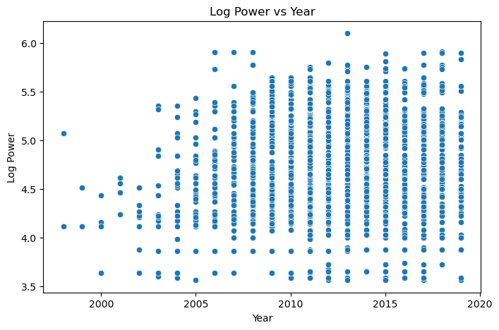

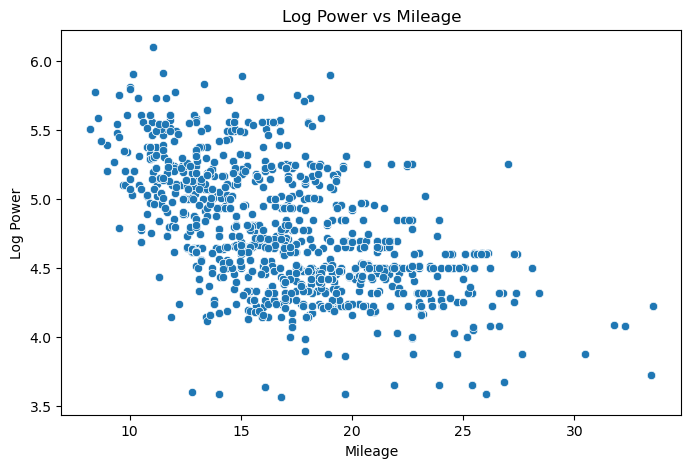

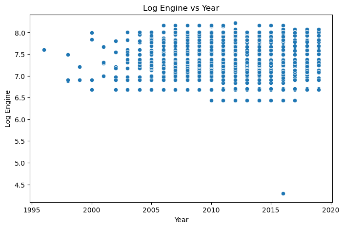

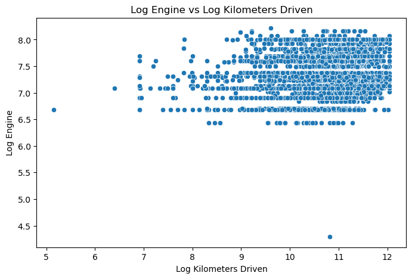

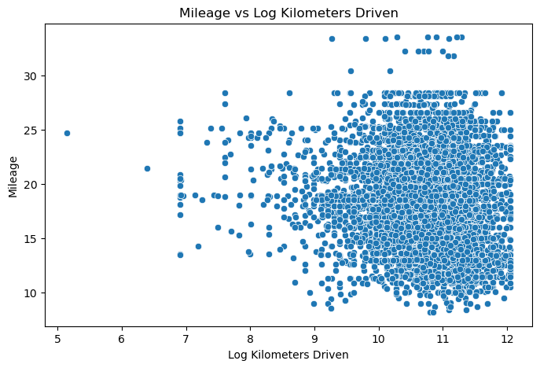

```python
# Scatter plot for Power vs Year
plt.figure(figsize=(8, 5))
sns.scatterplot(x=used_cars_data['Year'], y=used_cars_data['Log_Power'])
plt.title('Log Power vs Year')
plt.xlabel('Year')
plt.ylabel('Log Power')
plt.show()

# Scatter plot for Power vs Mileage
plt.figure(figsize=(8, 5))
sns.scatterplot(x=used_cars_data['Mileage'], y=used_cars_data['Log_Power'])
plt.title('Log Power vs Mileage')
plt.xlabel('Mileage')
plt.ylabel('Log Power')
plt.show()

# Scatter plot for Engine vs Year
plt.figure(figsize=(8, 5))
sns.scatterplot(x=used_cars_data['Year'], y=used_cars_data['Log_Engine'])
plt.title('Log Engine vs Year')
plt.xlabel('Year')
plt.ylabel('Log Engine')
plt.show()

# Scatter plot for Engine vs Kilometers Driven
plt.figure(figsize=(8, 5))
sns.scatterplot(x=used_cars_data['Log_Kilometers_Driven'], y=used_cars_data['Log_Engine'])
plt.title('Log Engine vs Log Kilometers Driven')
plt.xlabel('Log Kilometers Driven')
plt.ylabel('Log Engine')
plt.show()

# Scatter plot for Mileage vs Kilometers Driven
plt.figure(figsize=(8, 5))
sns.scatterplot(x=used_cars_data['Log_Kilometers_Driven'], y=used_cars_data['Mileage'])
plt.title('Mileage vs Log Kilometers Driven')
plt.xlabel('Log Kilometers Driven')
plt.ylabel('Mileage')
plt.show()
```

### Log Power vs Mileage:

- There is an inverse relationship here, with cars having higher power generally showing lower mileage. This could indicate that more powerful cars tend to consume more fuel or are typically designed for performance rather than fuel efficiency.

### Log Engine vs Year:

- Similar to power, engine sizes seem to have increased slightly over time, though the trend is not as strong. This could reflect technological evolution and changes in consumer preferences, where larger engines may have been more common in recent years.

### Log Engine vs Log Kilometers Driven:

- No strong correlation is observed between engine size and kilometers driven, indicating that engine size does not necessarily affect how long a car is used or the mileage it accrues.

### Mileage vs Log Kilometers Driven:

- This plot shows that there isn't a clear linear relationship between mileage and kilometers driven, suggesting that the efficiency of the vehicle doesn't necessarily decrease directly with higher usage.

### **Feature Engineering**

**Think about it:** The `Name` column in the current format might not be very useful in our analysis. Since the name contains both the brand name and the model name of the vehicle, the column would have too many unique values to be useful in prediction. Can we extract that information from that column?

- **Hint:** With 2041 unique names, car names are not going to be great predictors of the price in our current data. But we can process this column to extract important information for example brand name.

### Extract the Brand Name:

- For most car names, the brand is typically the first word. We can split the Name column by spaces and extract the first word as the brand name.

### Encoding the Brand:

- After extracting the brand, we can encode it using one-hot encoding or label encoding, depending on the model.

```python
# Extract brand name from the Name column
used_cars_data['Brand'] = used_cars_data['Name'].apply(lambda x: x.split()[0])

# Check the unique brands to understand the distribution
print(used_cars_data['Brand'].value_counts())
```

```
Brand
Maruti           1443
Hyundai          1299
Honda             739
Toyota            505
Volkswagen        372
Mercedes-Benz     363
Ford              349
Mahindra          328
BMW               307
Audi              277
Tata              228
Skoda             199
Renault           170
Chevrolet         151
Nissan            117
Land               51
Jaguar             46
Fiat               37
Mitsubishi         36
Mini               31
Volvo              28
Jeep               19
Datsun             17
Porsche            14
ISUZU               3
Force               3
Isuzu               2
Ambassador          1
Hindustan           1
OpelCorsa           1
Name: count, dtype: int64
```

```python
# Drop the original Name column as it's no longer needed
used_cars_data.drop(columns=['Name'], inplace=True)

# Standardize the brand names (convert all to uppercase for consistency)
used_cars_data['Brand'] = used_cars_data['Brand'].str.upper()

# Check the unique brands to confirm standardization
print(used_cars_data['Brand'].value_counts())

# Apply one-hot encoding to the Brand column
used_cars_data = pd.get_dummies(used_cars_data, columns=['Brand'], drop_first=True)
```

```
Brand
MARUTI           1443
HYUNDAI          1299
HONDA             739
TOYOTA            505
VOLKSWAGEN        372
MERCEDES-BENZ     363
FORD              349
MAHINDRA          328
BMW               307
AUDI              277
TATA              228
SKODA             199
RENAULT           170
CHEVROLET         151
NISSAN            117
LAND               51
JAGUAR             46
FIAT               37
MITSUBISHI         36
MINI               31
VOLVO              28
JEEP               19
DATSUN             17
PORSCHE            14
ISUZU               5
FORCE               3
AMBASSADOR          1
HINDUSTAN           1
OPELCORSA           1
Name: count, dtype: int64
```

```python
# Check the final dataset structure
print(used_cars_data.info())
```

```
<class 'pandas.core.frame.DataFrame'>
Index: 7137 entries, 0 to 7252
Data columns (total 45 columns):
 #   Column                 Non-Null Count  Dtype
---  ------                 --------------  -----
 0   S.No.                  7137 non-null   int64
 1   Location               7137 non-null   object
 2   Year                   7137 non-null   int64
 3   Kilometers_Driven      7137 non-null   float64
 4   Fuel_Type              7137 non-null   category
 5   Transmission           7137 non-null   category
 6   Owner_Type             7137 non-null   category
 7   Mileage                7135 non-null   float64
 8   Engine                 7103 non-null   float64
 9   Power                  7007 non-null   float64
```

[output cut: 38 more lines]

### Encoding Categorical Variables:

- Convert categorical variables like Fuel_Type, Transmission, Owner_Type, and Location into numerical values using techniques like one-hot encoding or label encoding.

#### Fuel_Type, Transmission, and Owner_Type:

- - These are nominal categorical variables with a manageable number of unique values.
  - **Best Approach:** One-Hot Encoding, as they do not have an ordinal relationship, and one-hot encoding will create a straightforward binary representation for each category.

#### Location:

- - This variable has a moderate number of unique values (likely representing city names), making it a nominal variable.
  - **Best Approach:** One-Hot Encoding, since it does not represent an ordinal relationship. This encoding will ensure that location differences are not forced into an arbitrary numerical order.

```python
# Perform one-hot encoding on categorical variables
used_cars_data = pd.get_dummies(used_cars_data, columns=['Fuel_Type', 'Transmission', 'Owner_Type', 'Location'], drop_first=True)

# Display the first few rows to verify
used_cars_data.head()
```

|  | S.No. | Year | Kilometers_Driven | Mileage | Engine | Power | Seats | New_price | Price | Log_Price | ... | Location_Bangalore | Location_Chennai | Location_Coimbatore | Location_Delhi | Location_Hyderabad | Location_Jaipur | Location_Kochi | Location_Kolkata | Location_Mumbai | Location_Pune |
| --- | --- | --- | --- | --- | --- | --- | --- | --- | --- | --- | --- | --- | --- | --- | --- | --- | --- | --- | --- | --- | --- |
| 0 | 0 | 2010 | 72000.0 | 26.60 | 998.0 | 58.16 | 5.0 | NaN | 1.75 | 1.011601 | ... | False | False | False | False | False | False | False | False | True | False |
| 1 | 1 | 2015 | 41000.0 | 19.67 | 1582.0 | 126.20 | 5.0 | NaN | 12.50 | 2.602690 | ... | False | False | False | False | False | False | False | False | False | True |
| 2 | 2 | 2011 | 46000.0 | 18.20 | 1199.0 | 88.70 | 5.0 | 8.61 | 4.50 | 1.704748 | ... | False | True | False | False | False | False | False | False | False | False |
| 3 | 3 | 2012 | 87000.0 | 20.77 | 1248.0 | 88.76 | 7.0 | NaN | 6.00 | 1.945910 | ... | False | True | False | False | False | False | False | False | False | False |
| 4 | 4 | 2013 | 40670.0 | 15.20 | 1968.0 | 140.80 | 5.0 | NaN | 17.74 | 2.930660 | ... | False | False | True | False | False | False | False | False | False | False |

5 rows × 57 columns

```python
# Check the data types of the newly created columns
print(used_cars_data.dtypes)
```

```
S.No.                          int64
Year                           int64
Kilometers_Driven            float64
Mileage                      float64
Engine                       float64
Power                        float64
Seats                        float64
New_price                    float64
Price                        float64
Log_Price                    float64
Log_Kilometers_Driven        float64
Log_Power                    float64
Log_Engine                   float64
Brand_AUDI                      bool
Brand_BMW                       bool
Brand_CHEVROLET                 bool
Brand_DATSUN                    bool
Brand_FIAT                      bool
Brand_FORCE                     bool
Brand_FORD                      bool
Brand_HINDUSTAN                 bool
Brand_HONDA                     bool
Brand_HYUNDAI                   bool
Brand_ISUZU                     bool
Brand_JAGUAR                    bool
Brand_JEEP                      bool
Brand_LAND                      bool
Brand_MAHINDRA                  bool
Brand_MARUTI                    bool
Brand_MERCEDES-BENZ             bool
Brand_MINI                      bool
Brand_MITSUBISHI                bool
Brand_NISSAN                    bool
Brand_OPELCORSA                 bool
Brand_PORSCHE                   bool
Brand_RENAULT                   bool
Brand_SKODA                     bool
Brand_TATA                      bool
Brand_TOYOTA                    bool
Brand_VOLKSWAGEN                bool
Brand_VOLVO                     bool
Fuel_Type_Diesel                bool
Fuel_Type_Petrol                bool
Transmission_Manual             bool
Owner_Type_Fourth & Above       bool
Owner_Type_Second               bool
Owner_Type_Third                bool
Location_Bangalore              bool
Location_Chennai                bool
Location_Coimbatore             bool
Location_Delhi                  bool
Location_Hyderabad              bool
Location_Jaipur                 bool
Location_Kochi                  bool
Location_Kolkata                bool
Location_Mumbai                 bool
Location_Pune                   bool
dtype: object
```

### Feature Creation:

- We could create features like the car’s age (2024 - Year) to replace or supplement Year, as age might better correlate with the car’s price.
- Interaction terms between Engine and Power might capture the effect of engine power on pricing more effectively.

```python
# Create 'Car_Age' feature
used_cars_data['Car_Age'] = 2024 - used_cars_data['Year']

# Create 'Engine_Power_Interaction' feature as the product of Engine and Power
used_cars_data['Engine_Power_Interaction'] = used_cars_data['Engine'] * used_cars_data['Power']

# Display the first few rows to verify
print(used_cars_data[['Year', 'Car_Age', 'Engine', 'Power', 'Engine_Power_Interaction']].head())
```

```
   Year  Car_Age  Engine   Power  Engine_Power_Interaction
0  2010       14   998.0   58.16                  58043.68
1  2015        9  1582.0  126.20                 199648.40
2  2011       13  1199.0   88.70                 106351.30
3  2012       12  1248.0   88.76                 110772.48
4  2013       11  1968.0  140.80                 277094.40
```

### **Missing value treatment**

### Imputation for Missing Values:

- Impute remaining missing values in Mileage, Engine, Power, and Seats. Depending on their distributions, we can use median or mean imputation, or try model-based imputation if necessary.

```python
# Check for missing values in the dataset again
print(used_cars_data.isnull().sum())
```

```
S.No.                           0
Year                            0
Kilometers_Driven               0
Mileage                         2
Engine                         34
Power                         130
Seats                          39
New_price                    6138
Price                        1219
Log_Price                    1219
Log_Kilometers_Driven           0
Log_Power                     130
Log_Engine                     34
Brand_AUDI                      0
Brand_BMW                       0
Brand_CHEVROLET                 0
Brand_DATSUN                    0
Brand_FIAT                      0
Brand_FORCE                     0
Brand_FORD                      0
Brand_HINDUSTAN                 0
Brand_HONDA                     0
Brand_HYUNDAI                   0
Brand_ISUZU                     0
Brand_JAGUAR                    0
Brand_JEEP                      0
Brand_LAND                      0
Brand_MAHINDRA                  0
Brand_MARUTI                    0
Brand_MERCEDES-BENZ             0
Brand_MINI                      0
Brand_MITSUBISHI                0
Brand_NISSAN                    0
Brand_OPELCORSA                 0
Brand_PORSCHE                   0
Brand_RENAULT                   0
Brand_SKODA                     0
Brand_TATA                      0
Brand_TOYOTA                    0
Brand_VOLKSWAGEN                0
Brand_VOLVO                     0
Fuel_Type_Diesel                0
Fuel_Type_Petrol                0
Transmission_Manual             0
Owner_Type_Fourth & Above       0
Owner_Type_Second               0
Owner_Type_Third                0
Location_Bangalore              0
Location_Chennai                0
Location_Coimbatore             0
Location_Delhi                  0
Location_Hyderabad              0
Location_Jaipur                 0
Location_Kochi                  0
Location_Kolkata                0
Location_Mumbai                 0
Location_Pune                   0
Car_Age                         0
Engine_Power_Interaction      130
dtype: int64
```

#### 1. Mileage (2 missing values)

- **Option 1:** Impute with the median of the Mileage column, as it is skewed and has only a few missing values. Median imputation can handle skewed data better.
- **Option 2:** Impute with the mean if the distribution is approximately normal.
- **Option 3:** Since there are only two missing values, it may not impact the dataset significantly if we decide to drop these rows.

#### 2. Engine (34 missing values)

- **Option 1:** Use median imputation, as Engine may have a skewed distribution.
- **Option 2:** If there is a relationship between Engine and other features (e.g., Power or Brand), we could try filling the missing values based on similar values within those groups.
- **Option 3:** Model-based imputation using KNNImputer or regression imputation with features like Power and Brand.

#### 3. Power (130 missing values)

- **Option 1:** Median imputation, as Power might also be skewed and have outliers.
- **Option 2:** Impute Power based on Engine and Brand, as power and engine size often correlate and may vary by car brand.
- **Option 3:** Use model-based imputation, such as KNNImputer, considering the larger number of missing values.

#### 4. Seats (39 missing values)

- **Option 1:** Mode imputation, as the number of seats is likely to have a limited set of typical values (e.g., 4, 5, 7).
- **Option 2:** Impute based on Brand or Type if there’s a common seat count associated with certain brands or categories.
- **Option 3:** Median imputation if it is numeric, though mode may better capture the distribution of this categorical-like feature.

#### 5. New_price (6138 missing values)

- **Option 1:** Drop the column, as the majority of the data is missing and filling it may not add substantial value to the model.
- **Option 2:** Impute with a representative value (mean or median) if the feature is essential, though this could add noise.
- **Option 3:** Use an external dataset or API to fill in missing values, though this might be impractical.

#### 6. Price and Log_Price (1219 missing values each)

- **Option 1:** Since Price is the target variable, it’s best to remove rows with missing prices if they are too numerous to reliably impute.
- **Option 2:** Model-based imputation, though it’s risky as we may end up introducing bias.

#### 7. Engine_Power_Interaction (130 missing values)

- This is derived from Engine and Power, so filling in those missing values will automatically resolve the missing values here. Once Engine and Power are imputed, recompute Engine_Power_Interaction.

### Explanation for Imputation Strategies Applied (My solutions)

In this project, we utilized various imputation methods to handle missing values effectively across different columns. These methods included both simple techniques (such as median imputation) and more sophisticated, context-based approaches (such as multiple regression imputation and imputation based on brand characteristics). Below is a detailed explanation of each step:

#### 1. Dropping New_price Column

- Since the New_price column had an overwhelming number of missing values, it was deemed unfeasible to impute with accuracy. Thus, the decision was made to drop this column to streamline the dataset for modeling.

#### 2. Imputation of Mileage with Median

**Objective:** To address missing values in the Mileage column by using a central tendency.

- **Method:** The median was chosen as it is less sensitive to outliers compared to the mean. This ensures that the imputed values are representative of the majority of data points, maintaining data integrity.

#### 3. Imputing Log_Power and Log_Engine Using a Linear Relationship

**Objective:** To leverage the strong linear relationship between Log_Power and Log_Engine observed in exploratory data analysis (EDA) for imputing missing values.

**Process:**

- **Temporary Column Creation:** We created temporary columns, Log_Engine_temp and Log_Power_temp, which filled missing values with the median to allow model training without missing values.
- **Step 1:** We used a linear regression model to predict Log_Power based on Log_Engine. The model was trained on rows with non-missing values for Log_Power and Log_Engine, and then predictions were made for rows with missing Log_Power.
- **Step 2:** Similarly, we trained another linear regression model to predict Log_Engine based on Log_Power to impute missing Log_Engine values.
- **Reverse Transformation:** Once Log_Power and Log_Engine were fully imputed, we used their exponentiated values to fill missing values in Power and Engine.

**Benefits:** This approach ensures that the imputations respect the inherent linear relationship in the data, leading to more realistic imputed values than simple median or mean imputation.

#### 4. Imputing Seats Based on Brand

**Objective:** To utilize the brand of a car to determine the most likely number of seats, given that certain brands typically have similar seating configurations.

**Process:**

- **Brand-Mode Calculation:** We calculated the mode (most frequent value) of Seats for each brand using one-hot encoded brand columns.
- **Custom Imputation Function:** A function was created to check each brand-specific column in a row. If a car belonged to a certain brand, the missing Seats value was filled with that brand’s mode.
- **Fallback to Median:** In cases where the brand information was not available, the median number of seats across all rows was used as a fallback.

**Benefits:** Imputing Seats based on the brand aligns with real-world automotive trends, where specific brands and models are known to have standard seating configurations. This method offers a more contextually accurate imputation compared to a general median or mean.

### Summary

These targeted imputation techniques were chosen to handle missing data in a way that preserves the structure and relationships within the dataset:

- **Median Imputation** for straightforward, centralized replacement.
- **Multiple Regression Imputation** for features with identifiable linear relationships.
- **Brand-Based Imputation** for categorical variables linked to specific characteristics like seating.

```python
used_cars_data.drop(columns=['New_price'], inplace=True)
```

```python
# Impute missing values in Mileage with the median
used_cars_data['Mileage'].fillna(used_cars_data['Mileage'].median(), inplace=True)
```

```python
# Fill temporary NaNs with median for Log_Engine and Log_Power to allow model training
used_cars_data['Log_Engine_temp'] = used_cars_data['Log_Engine'].fillna(used_cars_data['Log_Engine'].median())
used_cars_data['Log_Power_temp'] = used_cars_data['Log_Power'].fillna(used_cars_data['Log_Power'].median())

# Step 1: Impute Log_Power using Log_Engine
log_power_missing = used_cars_data[used_cars_data['Log_Power'].isnull()]
log_power_not_missing = used_cars_data[~used_cars_data['Log_Power'].isnull()]

# Train model for Log_Power based on Log_Engine
model_power = LinearRegression()
model_power.fit(log_power_not_missing[['Log_Engine_temp']], log_power_not_missing['Log_Power'])

# Predict missing Log_Power values
predicted_log_power = model_power.predict(log_power_missing[['Log_Engine_temp']])
used_cars_data.loc[log_power_missing.index, 'Log_Power'] = predicted_log_power

# Step 2: Impute Log_Engine using Log_Power
log_engine_missing = used_cars_data[used_cars_data['Log_Engine'].isnull()]
log_engine_not_missing = used_cars_data[~used_cars_data['Log_Engine'].isnull()]

# Train model for Log_Engine based on Log_Power
model_engine = LinearRegression()
model_engine.fit(log_engine_not_missing[['Log_Power_temp']], log_engine_not_missing['Log_Engine'])

# Predict missing Log_Engine values
predicted_log_engine = model_engine.predict(log_engine_missing[['Log_Power_temp']])
used_cars_data.loc[log_engine_missing.index, 'Log_Engine'] = predicted_log_engine

# Step 3: Reverse-transform Log_Engine and Log_Power to fill Engine and Power
used_cars_data['Engine'].fillna(np.exp(used_cars_data['Log_Engine']), inplace=True)
used_cars_data['Power'].fillna(np.exp(used_cars_data['Log_Power']), inplace=True)

# Drop temporary columns
used_cars_data.drop(columns=['Log_Engine_temp', 'Log_Power_temp'], inplace=True)
```

```python
# Create a dictionary to map each brand's one-hot encoded column to the most frequent 'Seats' value
brand_seats_mode = {}

# Loop through each brand column to calculate mode of 'Seats' for that brand
for brand_col in [col for col in used_cars_data.columns if col.startswith('Brand_')]:
    brand_name = brand_col.split('_')[1]  # Extract brand name from column name
    brand_seats_mode[brand_col] = used_cars_data.loc[used_cars_data[brand_col] == 1, 'Seats'].mode()[0]

# Function to impute missing Seats values
def impute_seats(row):
    if pd.isnull(row['Seats']):
        for brand_col in brand_seats_mode.keys():
            if row.get(brand_col, 0) == 1:
                return brand_seats_mode[brand_col]
        return used_cars_data['Seats'].median()  # Default to median if brand not found
    else:
        return row['Seats']

# Apply the function to impute missing values in Seats
used_cars_data['Seats'] = used_cars_data.apply(impute_seats, axis=1)
```

### Explanation for Imputation Strategy in Price Column

This section explains the approach used for handling missing values in the Price column by creating three distinct imputed versions: Median Imputation, Multiple Regression Imputation, and K-Nearest Neighbors (KNN) Imputation. Each method was designed to handle missing values by making the best use of available data patterns and correlations.

#### Step 1: Median Imputation

**Objective:** To impute missing values in Log_Price with a straightforward and statistically robust method using the median value.

- **Method:** For missing values in the Log_Price column, we filled them with the median of non-missing values in the same column.
- **Back Transformation:** Once Log_Price was imputed, the Price column was derived by exponentiating Log_Price_Filled_Median.
- **Advantages:** Median imputation is simple and doesn’t distort the distribution of data as much as mean imputation, making it particularly useful when the data has outliers or is not normally distributed.

#### Step 2: Multiple Regression Imputation

**Objective:** To predict missing Log_Price values based on the relationships observed with other important numerical features.

- **Feature Selection:** We identified Log_Power, Log_Engine, and Car_Age as strong predictors of Log_Price through bivariate analysis.
- **Standardization:** We scaled these features temporarily to ensure uniformity in magnitude, improving regression model accuracy.
- **Model Training:** Using only rows with non-missing values in Log_Price and selected features, we trained a Linear Regression model to predict Log_Price.
- **Imputation:** This trained model was then used to estimate Log_Price for rows where it was missing. After imputation, Price_Filled_Regression was calculated by exponentiating Log_Price_Filled_Regression.
- **Advantages:** Multiple Regression Imputation uses the linear relationship between Log_Price and other features, offering a more refined approach than simple median imputation by leveraging correlations in the dataset.

#### Step 3: KNN Imputation

**Objective:** To utilize the similarity between rows in both numerical and categorical features to predict missing values in Log_Price.

- **Feature Inclusion:** We included numerical predictors (Log_Power, Log_Engine, Car_Age) and categorical features (like Brand and Fuel_Type) in the KNN model. The categorical variables were already one-hot encoded, making them suitable for KNN.
- **KNN Model:** Using the KNN Imputer with k=5 neighbors, each missing Log_Price value was imputed by averaging the values of the five most similar rows.
- **Back Transformation:** After filling Log_Price_Filled_KNN, the corresponding Price_Filled_KNN column was computed by taking the exponent of Log_Price_Filled_KNN.
- **Advantages:** KNN Imputation takes into account both numerical and categorical feature similarities, making it effective for datasets where the target variable (Log_Price) depends on a complex combination of different features.

#### Summary of Imputation Results

The final imputed DataFrame `used_cars_data_imputed` contains three different versions of the imputed Log_Price and Price columns:

- **Log_Price_Filled_Median and Price_Filled_Median** (using median imputation)
- **Log_Price_Filled_Regression and Price_Filled_Regression** (using multiple regression imputation)
- **Log_Price_Filled_KNN and Price_Filled_KNN** (using KNN imputation)

Each approach offers a unique perspective on missing value handling. These separate imputations allow us to evaluate and compare model performance across different imputation methods, ultimately selecting the best one for accurate price prediction.

```python
# Copying data for separate imputations
used_cars_data_imputed = used_cars_data.copy()

# Step 1: Median Imputation
# Fill Log_Price with median and compute Price from it
used_cars_data_imputed['Log_Price_Filled_Median'] = used_cars_data['Log_Price'].fillna(used_cars_data['Log_Price'].median())
used_cars_data_imputed['Price_Filled_Median'] = np.exp(used_cars_data_imputed['Log_Price_Filled_Median'])

# Step 2: Multiple Regression Imputation
# Columns to be used for imputations
imputation_cols = ['Log_Power', 'Log_Engine', 'Car_Age']

# Standardize columns temporarily for imputations
scaler = StandardScaler()
normalized_data = used_cars_data.copy()
normalized_data[imputation_cols] = scaler.fit_transform(normalized_data[imputation_cols])

# Train regression model on non-missing values
train_data = normalized_data.dropna(subset=['Log_Price'] + imputation_cols)
X_train = train_data[imputation_cols]
y_train = train_data['Log_Price']
reg_model = LinearRegression()
reg_model.fit(X_train, y_train)

# Predict missing values for Log_Price using multiple regression
test_data = normalized_data[normalized_data['Log_Price'].isnull()]
X_test = test_data[imputation_cols]
log_price_pred_regression = reg_model.predict(X_test)

# Fill the predicted values back into the DataFrame
used_cars_data_imputed.loc[used_cars_data_imputed['Log_Price'].isnull(), 'Log_Price_Filled_Regression'] = log_price_pred_regression
used_cars_data_imputed['Log_Price_Filled_Regression'].fillna(used_cars_data['Log_Price'], inplace=True)
used_cars_data_imputed['Price_Filled_Regression'] = np.exp(used_cars_data_imputed['Log_Price_Filled_Regression'])

# Step 3: KNN Imputation
# Define features including the categorical columns for KNN
categorical_cols = [col for col in used_cars_data.columns if 'Brand_' in col or 'Fuel_Type_' in col or 'Transmission_' in col or 'Owner_Type_' in col or 'Location_' in col]
knn_features = imputation_cols + categorical_cols + ['Log_Price']
knn_imputer = KNNImputer(n_neighbors=5)
knn_data = normalized_data[knn_features]
knn_imputed = knn_imputer.fit_transform(knn_data)

# Save KNN-imputed values
used_cars_data_imputed['Log_Price_Filled_KNN'] = knn_imputed[:, -1]
used_cars_data_imputed['Price_Filled_KNN'] = np.exp(used_cars_data_imputed['Log_Price_Filled_KNN'])

# Summary of Imputed Columns
imputed_columns = used_cars_data_imputed[['Log_Price_Filled_Median', 'Price_Filled_Median',
                                          'Log_Price_Filled_Regression', 'Price_Filled_Regression',
                                          'Log_Price_Filled_KNN', 'Price_Filled_KNN']]

# Display the DataFrame with different imputed values
print("Different imputed versions of Log_Price and Price:")
print(imputed_columns.head())
```

```
Different imputed versions of Log_Price and Price:
   Log_Price_Filled_Median  Price_Filled_Median  Log_Price_Filled_Regression  \
0                 1.011601                 2.75                     1.011601
1                 2.602690                13.50                     2.602690
2                 1.704748                 5.50                     1.704748
3                 1.945910                 7.00                     1.945910
4                 2.930660                18.74                     2.930660

   Price_Filled_Regression  Log_Price_Filled_KNN  Price_Filled_KNN
0                     2.75              1.011601              2.75
1                    13.50              2.602690             13.50
2                     5.50              1.704748              5.50
3                     7.00              1.945910              7.00
4                    18.74              2.930660             18.74
```

```python
# Filter only rows where 'Log_Price' was initially missing
missing_log_price_rows = used_cars_data[used_cars_data['Log_Price'].isnull()]

# Select columns with different imputation results
comparison_columns = missing_log_price_rows[['Log_Price', 'Price']].copy()
comparison_columns['Log_Price_Filled_Median'] = used_cars_data_imputed['Log_Price_Filled_Median']
comparison_columns['Price_Filled_Median'] = used_cars_data_imputed['Price_Filled_Median']
comparison_columns['Log_Price_Filled_Regression'] = used_cars_data_imputed['Log_Price_Filled_Regression']
comparison_columns['Price_Filled_Regression'] = used_cars_data_imputed['Price_Filled_Regression']
comparison_columns['Log_Price_Filled_KNN'] = used_cars_data_imputed['Log_Price_Filled_KNN']
comparison_columns['Price_Filled_KNN'] = used_cars_data_imputed['Price_Filled_KNN']

# Display the rows where 'Log_Price' was missing, with filled values
print("Comparison of Imputed Values for Missing Log_Price and Price Rows:")
print(comparison_columns)
```

```
Comparison of Imputed Values for Missing Log_Price and Price Rows:
      Log_Price  Price  Log_Price_Filled_Median  Price_Filled_Median  \
6019        NaN    NaN                  1.88707                  6.6
6020        NaN    NaN                  1.88707                  6.6
6021        NaN    NaN                  1.88707                  6.6
6022        NaN    NaN                  1.88707                  6.6
6023        NaN    NaN                  1.88707                  6.6
...         ...    ...                      ...                  ...
7248        NaN    NaN                  1.88707                  6.6
7249        NaN    NaN                  1.88707                  6.6
7250        NaN    NaN                  1.88707                  6.6
7251        NaN    NaN                  1.88707                  6.6
7252        NaN    NaN                  1.88707                  6.6

      Log_Price_Filled_Regression  Price_Filled_Regression  \
```

[output cut: 26 more lines]

```python
# Adding the imputed columns to the main DataFrame
used_cars_data['Log_Price_Filled_Median'] = used_cars_data_imputed['Log_Price_Filled_Median']
used_cars_data['Price_Filled_Median'] = used_cars_data_imputed['Price_Filled_Median']
used_cars_data['Log_Price_Filled_Regression'] = used_cars_data_imputed['Log_Price_Filled_Regression']
used_cars_data['Price_Filled_Regression'] = used_cars_data_imputed['Price_Filled_Regression']
used_cars_data['Log_Price_Filled_KNN'] = used_cars_data_imputed['Log_Price_Filled_KNN']
used_cars_data['Price_Filled_KNN'] = used_cars_data_imputed['Price_Filled_KNN']
```

```python
used_cars_data.info()
```

```
<class 'pandas.core.frame.DataFrame'>
Index: 7137 entries, 0 to 7252
Data columns (total 64 columns):
 #   Column                       Non-Null Count  Dtype
---  ------                       --------------  -----
 0   S.No.                        7137 non-null   int64
 1   Year                         7137 non-null   int64
 2   Kilometers_Driven            7137 non-null   float64
 3   Mileage                      7137 non-null   float64
 4   Engine                       7137 non-null   float64
 5   Power                        7137 non-null   float64
 6   Seats                        7137 non-null   float64
 7   Price                        5918 non-null   float64
 8   Log_Price                    5918 non-null   float64
 9   Log_Kilometers_Driven        7137 non-null   float64
```

[output cut: 56 more lines]

### Scaling and Normalization:

- Scale numerical features like Kilometers_Driven, Mileage, Engine, and Power to improve model performance, especially for algorithms sensitive to feature scaling (e.g., linear regression, SVM).

```python
# List of numerical features to scale
numerical_features = [
    'Kilometers_Driven', 'Mileage', 'Engine', 'Power',
    'Car_Age', 'Engine_Power_Interaction',
    'Log_Kilometers_Driven', 'Log_Engine', 'Log_Power'
]

# Initialize the scaler
scaler = StandardScaler()

# Apply scaling to the numerical features
scaled_data = used_cars_data.copy()
scaled_data[numerical_features] = scaler.fit_transform(scaled_data[numerical_features])

# Display scaled data for verification
print(scaled_data[numerical_features].head())

# Check the scaled data
print(used_cars_data[numerical_features].describe())
```

```
   Kilometers_Driven   Mileage    Engine     Power   Car_Age  \
0           0.464394  1.990069 -1.083576 -1.072048  1.065764
1          -0.492034  0.311953 -0.035041  0.304634 -0.493619
2          -0.337771 -0.044011 -0.722693 -0.454120  0.753887
3           0.927181  0.578321 -0.634717 -0.452906  0.442011
4          -0.502215 -0.770468  0.657997  0.600042  0.130134

   Engine_Power_Interaction  Log_Kilometers_Driven  Log_Engine  Log_Power
0                 -0.867297               0.607166   -1.268853  -1.391576
1                 -0.014780              -0.189983    0.130959   0.524876
2                 -0.576466              -0.027085   -0.711382  -0.349564
3                 -0.549849               0.875070   -0.589678  -0.347890
4                  0.451476              -0.201423    0.794504   0.796896
       Kilometers_Driven      Mileage       Engine        Power      Car_Age  \
count        7137.000000  7137.000000  7137.000000  7137.000000  7137.000000
mean        56947.932358    18.381749  1601.516966   111.144039    10.582738
std         32414.552539     4.129920   557.006769    49.426640     3.206622
min           171.000000     8.200000    72.000000    34.200000     5.000000
25%         33931.000000    15.400000  1198.000000    75.000000     8.000000
50%         53190.000000    18.250000  1461.000000    93.700000    10.000000
75%         73000.000000    21.100000  1968.000000   138.030000    12.000000
max        170273.920000    33.540000  3696.000000   444.000000    28.000000

       Engine_Power_Interaction  Log_Kilometers_Driven   Log_Engine  \
count              7.007000e+03            7137.000000  7137.000000
mean               2.021034e+05              10.755550     7.324012
std                1.661138e+05               0.706421     0.328869
min                2.952000e+03               5.147494     4.290459
25%                9.444330e+04              10.432114     7.089243
50%                1.376456e+05              10.881644     7.287561
75%                2.755200e+05              11.198228     7.585281
max                1.284936e+06              12.045170     8.215277

         Log_Power
count  7137.000000
mean      4.636102
std       0.399472
min       3.561046
25%       4.330733
50%       4.550714
75%       4.934690
max       6.098074
```

### Explanation

**Scaling Approach:**

- Here, we're using `StandardScaler`, which standardizes features by removing the mean and scaling to unit variance.

**Numerical Columns:**

- Only the relevant numerical features that would benefit from scaling are included. The boolean columns and encoded categorical features are excluded as they don't require scaling.

```python
# List of columns related to price and their imputed versions to scale
price_columns = [
    'Price', 'Log_Price',
    'Price_Filled_Median', 'Log_Price_Filled_Median',
    'Price_Filled_Regression', 'Log_Price_Filled_Regression',
    'Price_Filled_KNN', 'Log_Price_Filled_KNN'
]

# Using StandardScaler for consistency with previous scaling
scaler_price = StandardScaler()
used_cars_data[price_columns] = scaler_price.fit_transform(used_cars_data[price_columns])

# Checking the scaled columns
print(used_cars_data[price_columns].describe())
```

```
              Price     Log_Price  Price_Filled_Median  \
count  5.918000e+03  5.918000e+03         7.137000e+03
mean  -6.483492e-17  2.629416e-16         7.964610e-18
std    1.000084e+00  1.000084e+00         1.000070e+00
min   -8.416929e-01 -2.250862e+00        -8.504406e-01
25%   -5.485693e-01 -6.931728e-01        -4.932804e-01
50%   -3.474060e-01 -1.695947e-01        -3.131383e-01
75%    5.013089e-02  4.973126e-01        -3.199178e-02
max    8.414691e+00  3.519603e+00         9.211482e+00

       Log_Price_Filled_Median  Price_Filled_Regression  \
count             7.137000e+03             7.137000e+03
mean              1.592922e-16             2.150445e-16
std               1.000070e+00             1.000070e+00
min              -2.434052e+00            -9.673612e-01
25%              -6.092917e-01            -5.543890e-01
50%              -1.540557e-01            -3.315236e-01
75%               3.595407e-01             8.888154e-02
max               3.887403e+00             8.919416e+00

       Log_Price_Filled_Regression  Price_Filled_KNN  Log_Price_Filled_KNN
count                 7.137000e+03      7.137000e+03          7.137000e+03
mean                 -8.761071e-17      8.362840e-17         -1.015488e-16
std                   1.000070e+00      1.000070e+00          1.000070e+00
min                  -3.839125e+00     -8.553963e-01         -2.277148e+00
25%                  -6.868535e-01     -5.542367e-01         -7.000219e-01
50%                  -1.374473e-01     -3.475585e-01         -1.699106e-01
75%                   5.300892e-01      5.910757e-02          5.030016e-01
max                   3.590317e+00      8.654752e+00          3.565321e+00
```

## **Important Insights from EDA and Data Preprocessing**

What are the the most important observations and insights from the data based on the EDA and Data Preprocessing performed?

### 1. Price Distribution and Missing Values:

- **Log Price Transformation:** The distribution of the Price column was skewed, so we transformed it to Log_Price to achieve a more normalized distribution. This helped to handle extreme values better and improved the reliability of statistical analyses.
- **Handling Missing Values in Price:** Missing values in Price were substantial, and we tried multiple imputation techniques (median, multiple regression, KNN) to retain the dataset’s completeness without sacrificing too much data.

### 2. Key Features Influencing Price:

- **Engine, Power, and Car Age:** The features Engine, Power, and Car_Age were identified as some of the strongest predictors of Price. Through bivariate analysis, these features showed significant linear relationships with Price, indicating their importance in predicting car prices.
- **Interaction Term:** An interaction term between Engine and Power was created (Engine_Power_Interaction), capturing the effect of engine power more precisely. This term could potentially improve the model's predictive power as it emphasizes the combined effect of these two features on price.

### 4. Brand Analysis:

- **High Brand Influence:** Certain brands like Maruti, Hyundai, and Honda were more frequent in the dataset and tended to have lower prices, while luxury brands like Mercedes-Benz, BMW, and Audi had higher prices. One-hot encoding of the Brand column allowed us to incorporate brand influence into the model effectively.
- **Brand-Based Missing Value Imputation:** For certain features like Seats, missing values were imputed based on typical seat configurations for specific brands, helping to preserve brand-related nuances in the data.

### 5. Fuel Type and Transmission:

- **Fuel_Type and Transmission:** These categorical features were transformed through one-hot encoding and provided useful insights about vehicle type. For example, diesel cars and automatic transmissions generally corresponded to higher prices, reflecting preferences for these specifications in the market.

### 7. Location and Owner Type Influence:

- **Location Impact:** Different cities displayed varying price levels, with metro cities like Bangalore and Delhi typically having higher prices. This may reflect regional market demands or socioeconomic differences.
- **Owner Type:** First-owner cars had higher resale values, while third-owner or fourth-owner cars generally had lower prices due to perceived depreciation and lower buyer interest.

### 9. Multiple Imputation Techniques for Completeness:

- **Comparison of Imputation Methods:** Different imputation methods (median, regression, and KNN) were tested for filling missing values in Price and Log_Price. This allows us to compare these versions during modeling and assess which approach yields the best predictive accuracy.

## **Building Various Models**

1. What we want to predict is the "Price". We will use the normalized version 'price_log' for modeling.
2. Before we proceed to the model, we'll have to encode categorical features. We will drop categorical features like Name.
3. We'll split the data into train and test, to be able to evaluate the model that we build on the train data.
4. Build Regression models using train data.
5. Evaluate the model performance.

### **Split the Data**

Step1: Seperating the indepdent variables (X) and the dependent variable (y).

Step2: Encode the categorical variables in X using pd.dummies.

Step3: Split the data into train and test using train_test_split.

**Question:**

1. Why we should drop 'Name','Price','price_log','Kilometers_Driven' from X before splitting?

### Step 1: Preparing the Data

**Objective:** Separate independent variables (X) from the dependent variable (y), encode categorical features, and split the data into training and testing sets.

#### 1.1 Separate X and y

- Since we want to predict Price, we'll use Log_Price (the normalized version) as our target (y) and treat all other relevant columns as features (X).

#### 1.2 Dropping Certain Columns

**Columns to drop:**

- **Name:** It is unique for each vehicle and does not contribute meaningful predictive information. It’s a high-cardinality feature with too many unique values.
- **Price:** We’re predicting this value, so it should not be part of the features.
- **Log_Price:** This is the transformed target variable, so it should also be dropped from X.
- **Kilometers_Driven:** Since we have Log_Kilometers_Driven, we can drop the original to avoid redundancy and multicollinearity issues.

#### 1.3 Encode Categorical Variables

- Since categorical variables have already been one-hot encoded, we’ll proceed without additional encoding. All categorical variables should now be binary or boolean, which most regression algorithms can handle.

#### 1.4 Train-Test Split

- We’ll split the data into training and testing sets to evaluate model performance. A typical split ratio is 80% training and 20% testing.

For Regression Problems, some of the algorithms used are :

**1) Linear Regression**  
**2) Ridge / Lasso Regression**  
**3) Decision Trees**  
**4) Random Forest**

### Explanation of Key Steps

#### Feature Selection:

- We defined a minimal feature set for linear regression models and a broader feature set for tree-based models, including redundant features like both Engine and Log_Engine for tree models.

#### Encoding Categorical Features:

- The one-hot encoded categorical features were included in both X_lin_reg and X_tree_model for consistency.

#### Imputation Methods Comparison:

- The script trains models using each imputed version of Log_Price:
  - Median Imputation
  - Multiple Regression Imputation
  - KNN Imputation

#### Model Training and Evaluation:

- We trained Linear Regression, Ridge, and Lasso on the X_lin_reg feature set and Decision Tree and Random Forest on X_tree_model.
- For each model and imputation method, the Mean Squared Error (MSE) and R² score for training and testing sets were printed to evaluate performance.

```python
import warnings
warnings.filterwarnings("ignore")
```

```python
# Feature Selection
# Selecting features for linear regression (minimal feature set)
lin_reg_features = [
    'Log_Kilometers_Driven', 'Log_Engine', 'Log_Power',
    'Car_Age']

# Selecting features for tree-based models (wider feature set)
tree_model_features = [
    'Kilometers_Driven', 'Log_Kilometers_Driven', 'Engine',
    'Log_Engine', 'Power', 'Log_Power', 'Seats',
    'Car_Age']

# Categorical features (already one-hot encoded)
categorical_features = [col for col in used_cars_data.columns if 'Brand_' in col or 'Fuel_Type_' in col or 'Transmission_' in col or 'Owner_Type_' in col or 'Location_' in col]

# Target Variables (Different Imputations)
y_median = used_cars_data['Log_Price_Filled_Median']
y_regression = used_cars_data['Log_Price_Filled_Regression']
y_knn = used_cars_data['Log_Price_Filled_KNN']

# Final feature sets for linear and tree models
X_lin_reg = used_cars_data[lin_reg_features + categorical_features]
X_tree_model = used_cars_data[tree_model_features + categorical_features]
```

```python
# Helper function to train and evaluate models
def train_and_evaluate(X, y, method_name, model_type="Linear"):
    # Split the data
    X_train, X_test, y_train, y_test = train_test_split(X, y, test_size=0.2, random_state=42)

    # Initialize the model
    if model_type == "Linear":
        model = LinearRegression()
    elif model_type == "Ridge":
        model = Ridge(alpha=1.0)
    elif model_type == "Lasso":
        model = Lasso(alpha=0.1)
    elif model_type == "Decision Tree":
        model = DecisionTreeRegressor(random_state=42)
    elif model_type == "Random Forest":
        model = RandomForestRegressor(n_estimators=100, random_state=42)
    else:
        raise ValueError("Unsupported model type")

    # Train the model
    model.fit(X_train, y_train)

    # Predict and evaluate
    y_pred_train = model.predict(X_train)
    y_pred_test = model.predict(X_test)

    # Calculate metrics
    mse_train = mean_squared_error(y_train, y_pred_train)
    mse_test = mean_squared_error(y_test, y_pred_test)
    r2_train = r2_score(y_train, y_pred_train)
    r2_test = r2_score(y_test, y_pred_test)

    print(f"{method_name} - {model_type}:")
    print(f"  Train MSE: {mse_train:.4f}, Test MSE: {mse_test:.4f}")
    print(f"  Train R2: {r2_train:.4f}, Test R2: {r2_test:.4f}\n")
```

```python
# 1. Linear Regression with different imputations
train_and_evaluate(X_lin_reg, y_median, "Median Imputation", model_type="Linear")
train_and_evaluate(X_lin_reg, y_regression, "Multiple Regression Imputation", model_type="Linear")
train_and_evaluate(X_lin_reg, y_knn, "KNN Imputation", model_type="Linear")

# 2. Ridge and Lasso Regression with different imputations
train_and_evaluate(X_lin_reg, y_median, "Median Imputation", model_type="Ridge")
train_and_evaluate(X_lin_reg, y_regression, "Multiple Regression Imputation", model_type="Ridge")
train_and_evaluate(X_lin_reg, y_knn, "KNN Imputation", model_type="Ridge")

train_and_evaluate(X_lin_reg, y_median, "Median Imputation", model_type="Lasso")
train_and_evaluate(X_lin_reg, y_regression, "Multiple Regression Imputation", model_type="Lasso")
train_and_evaluate(X_lin_reg, y_knn, "KNN Imputation", model_type="Lasso")

# 3. Decision Tree Regressor with different imputations
train_and_evaluate(X_tree_model, y_median, "Median Imputation", model_type="Decision Tree")
train_and_evaluate(X_tree_model, y_regression, "Multiple Regression Imputation", model_type="Decision Tree")
train_and_evaluate(X_tree_model, y_knn, "KNN Imputation", model_type="Decision Tree")

# 4. Random Forest Regressor with different imputations
train_and_evaluate(X_tree_model, y_median, "Median Imputation", model_type="Random Forest")
train_and_evaluate(X_tree_model, y_regression, "Multiple Regression Imputation", model_type="Random Forest")
train_and_evaluate(X_tree_model, y_knn, "KNN Imputation", model_type="Random Forest")

print("Modeling and Evaluation Completed.")
```

```
Median Imputation - Linear:
  Train MSE: 0.2213, Test MSE: 0.2519
  Train R2: 0.7794, Test R2: 0.7450

Multiple Regression Imputation - Linear:
  Train MSE: 0.0741, Test MSE: 0.0938
  Train R2: 0.9261, Test R2: 0.9052

KNN Imputation - Linear:
  Train MSE: 0.0666, Test MSE: 0.0845
  Train R2: 0.9336, Test R2: 0.9149

Median Imputation - Ridge:
  Train MSE: 0.2214, Test MSE: 0.2511
  Train R2: 0.7793, Test R2: 0.7458

Multiple Regression Imputation - Ridge:
  Train MSE: 0.0741, Test MSE: 0.0933
  Train R2: 0.9261, Test R2: 0.9057

KNN Imputation - Ridge:
  Train MSE: 0.0666, Test MSE: 0.0841
  Train R2: 0.9335, Test R2: 0.9153

Median Imputation - Lasso:
  Train MSE: 0.3718, Test MSE: 0.3792
  Train R2: 0.6294, Test R2: 0.6160

Multiple Regression Imputation - Lasso:
  Train MSE: 0.2131, Test MSE: 0.2239
  Train R2: 0.7875, Test R2: 0.7737

KNN Imputation - Lasso:
  Train MSE: 0.2310, Test MSE: 0.2439
  Train R2: 0.7694, Test R2: 0.7542

Median Imputation - Decision Tree:
  Train MSE: 0.0002, Test MSE: 0.4768
  Train R2: 0.9998, Test R2: 0.5172

Multiple Regression Imputation - Decision Tree:
  Train MSE: 0.0001, Test MSE: 0.1431
  Train R2: 0.9999, Test R2: 0.8553

KNN Imputation - Decision Tree:
  Train MSE: 0.0000, Test MSE: 0.1104
  Train R2: 1.0000, Test R2: 0.8888

Median Imputation - Random Forest:
  Train MSE: 0.0344, Test MSE: 0.2412
  Train R2: 0.9657, Test R2: 0.7558

Multiple Regression Imputation - Random Forest:
  Train MSE: 0.0101, Test MSE: 0.0852
  Train R2: 0.9899, Test R2: 0.9138

KNN Imputation - Random Forest:
  Train MSE: 0.0075, Test MSE: 0.0675
  Train R2: 0.9925, Test R2: 0.9320

Modeling and Evaluation Completed.
```

### **Hyperparameter Tuning: Decision Tree**

```python
# Split data for each target variable once to keep consistency
X_train, X_test, y_train_median, y_test_median = train_test_split(X_tree_model, y_median, test_size=0.2, random_state=42)
_, _, y_train_regression, y_test_regression = train_test_split(X_tree_model, y_regression, test_size=0.2, random_state=42)
_, _, y_train_knn, y_test_knn = train_test_split(X_tree_model, y_knn, test_size=0.2, random_state=42)
```

```python
### 1. Hyperparameter Tuning for Decision Tree
def tune_decision_tree(X_train, y_train):
    param_grid = {
        'max_depth': [None, 10, 20, 30, 40],
        'min_samples_split': [2, 5, 10],
        'min_samples_leaf': [1, 2, 4]
    }
    grid_search = GridSearchCV(DecisionTreeRegressor(random_state=42), param_grid, cv=5, scoring='r2')
    grid_search.fit(X_train, y_train)
    print("Best parameters for Decision Tree:", grid_search.best_params_)
    return grid_search.best_estimator_

# Tune Decision Tree for each target variable
dt_model_median = tune_decision_tree(X_train, y_train_median)
dt_model_regression = tune_decision_tree(X_train, y_train_regression)
dt_model_knn = tune_decision_tree(X_train, y_train_knn)
```

```
Best parameters for Decision Tree: {'max_depth': 10, 'min_samples_leaf': 4, 'min_samples_split': 10}
Best parameters for Decision Tree: {'max_depth': 10, 'min_samples_leaf': 2, 'min_samples_split': 10}
Best parameters for Decision Tree: {'max_depth': 20, 'min_samples_leaf': 2, 'min_samples_split': 10}
```

**Feature Importance**

```python
### 2. Feature Importance for Decision Tree
def show_feature_importance(model, X, model_name):
    importance = model.feature_importances_
    feature_importance = pd.DataFrame({'Feature': X.columns, 'Importance': importance})
    feature_importance = feature_importance.sort_values(by='Importance', ascending=False)
    print(f"\n{model_name} Feature Importance:\n", feature_importance.head(10))

# Display feature importance for tuned Decision Trees
show_feature_importance(dt_model_median, X_train, "Decision Tree (Median Imputation)")
show_feature_importance(dt_model_regression, X_train, "Decision Tree (Regression Imputation)")
show_feature_importance(dt_model_knn, X_train, "Decision Tree (KNN Imputation)")
```

```
Decision Tree (Median Imputation) Feature Importance:
                   Feature  Importance
4                   Power    0.579869
7                 Car_Age    0.218585
5               Log_Power    0.086068
3              Log_Engine    0.020365
1   Log_Kilometers_Driven    0.014229
0       Kilometers_Driven    0.013899
2                  Engine    0.013143
6                   Seats    0.005796
25             Brand_MINI    0.005406
32             Brand_TATA    0.004145

Decision Tree (Regression Imputation) Feature Importance:
                   Feature  Importance
```

[output cut: 23 more lines]

### **Hyperparameter Tuning: Random Forest**

```python
### 3. Hyperparameter Tuning for Random Forest using RandomizedSearchCV
def tune_random_forest_random(X_train, y_train, n_iter=100):
    param_grid = {
        'max_depth': [None, 10, 20, 30, 40],
        'min_samples_split': [2, 5, 10],
        'min_samples_leaf': [1, 2, 4]
    }
    random_search = RandomizedSearchCV(
        RandomForestRegressor(random_state=42),
        param_distributions=param_grid,
        n_iter=n_iter,
        cv=3,                                # Reduced cross-validation folds to 3
        scoring='r2',
        n_jobs=-1                            # Parallel processing
    )
    random_search.fit(X_train, y_train)
    print("Best parameters for Random Forest (Randomized Search):", random_search.best_params_)
    return random_search.best_estimator_

# Tune Random Forest for each target variable
rf_model_median = tune_random_forest_random(X_train, y_train_median)
rf_model_regression = tune_random_forest_random(X_train, y_train_regression)
rf_model_knn = tune_random_forest_random(X_train, y_train_knn)
```

```
Best parameters for Random Forest (Randomized Search): {'min_samples_split': 10, 'min_samples_leaf': 1, 'max_depth': 10}
Best parameters for Random Forest (Randomized Search): {'min_samples_split': 5, 'min_samples_leaf': 1, 'max_depth': 30}
Best parameters for Random Forest (Randomized Search): {'min_samples_split': 2, 'min_samples_leaf': 1, 'max_depth': 30}
```

**Feature Importance**

```python
### 4. Feature Importance for Random Forest
# Display feature importance for tuned Random Forest models
show_feature_importance(rf_model_median, X_train, "Random Forest (Median Imputation)")
show_feature_importance(rf_model_regression, X_train, "Random Forest (Regression Imputation)")
show_feature_importance(rf_model_knn, X_train, "Random Forest (KNN Imputation)")
```

```
Random Forest (Median Imputation) Feature Importance:
                   Feature  Importance
5               Log_Power    0.336325
4                   Power    0.316177
7                 Car_Age    0.209384
0       Kilometers_Driven    0.016323
1   Log_Kilometers_Driven    0.015918
3              Log_Engine    0.013455
2                  Engine    0.013248
6                   Seats    0.006057
25             Brand_MINI    0.005879
38    Transmission_Manual    0.005530

Random Forest (Regression Imputation) Feature Importance:
                   Feature  Importance
```

[output cut: 23 more lines]

### Using Both Original and Log-Transformed Features

#### Capturing Linear and Non-Linear Relationships:

- The relationship between Engine/Power and Price may not be strictly linear. By using both the original and log-transformed values, we allow models to capture both linear and non-linear trends.
- For instance, the log-transformed versions (Log_Engine and Log_Power) can help linearize skewed data distributions, which is particularly useful for linear models like Linear Regression.

#### Reducing Impact of Outliers:

- Log transformation reduces the range of large values and makes the data more "normal." This can minimize the influence of outliers, which is especially useful for models sensitive to outliers.
- Including both the original and log-transformed features lets models weigh both scales, potentially improving robustness.

#### Improving Model Flexibility:

- For complex models like Decision Trees and Random Forests, adding both versions increases the model's flexibility. Trees can then choose whichever version of the feature gives a better split, leading to improved performance.

#### Correlation and Feature Interactions:

- During EDA, it was observed that log-transformed features like Log_Engine and Log_Power had strong linear correlations with Price. By keeping both versions, we provide models with alternative ways to leverage these correlations for different interactions or patterns.

### When to Remove Redundant Features

- For simpler models or to reduce overfitting, it can sometimes be beneficial to keep only one version (original or log) if they provide similar information. However, in complex modeling (e.g., tree-based models), having both versions often enriches the model's ability to learn nuanced patterns, so we retain both unless there are strong reasons (like multicollinearity) to remove them.

```python
# Define selected features based on importance
selected_features = ['Log_Power', 'Power', 'Car_Age', 'Kilometers_Driven', 'Log_Engine', 'Engine']

# Prepare data with selected features
X_final = used_cars_data[selected_features]

# Target variables (using the three imputed versions for comparison)
y_median = used_cars_data['Price_Filled_Median']
y_regression = used_cars_data['Price_Filled_Regression']
y_knn = used_cars_data['Price_Filled_KNN']

# Split data
X_train, X_test, y_train_median, y_test_median = train_test_split(X_final, y_median, test_size=0.2, random_state=42)
_, _, y_train_regression, y_test_regression = train_test_split(X_final, y_regression, test_size=0.2, random_state=42)
_, _, y_train_knn, y_test_knn = train_test_split(X_final, y_knn, test_size=0.2, random_state=42)

### 1. Final Decision Tree Model with Tuned Parameters
def build_final_decision_tree(X_train, y_train, best_params):
    model = DecisionTreeRegressor(random_state=42, **best_params)
    model.fit(X_train, y_train)
    return model

# Using the best parameters obtained from tuning
best_params_dt_median = {'max_depth': 10, 'min_samples_leaf': 4, 'min_samples_split': 10}
best_params_dt_regression = {'max_depth': 10, 'min_samples_leaf': 2, 'min_samples_split': 10}
best_params_dt_knn = {'max_depth': 20, 'min_samples_leaf': 2, 'min_samples_split': 10}

# Build and evaluate final Decision Tree models
dt_model_median = build_final_decision_tree(X_train, y_train_median, best_params_dt_median)
dt_model_regression = build_final_decision_tree(X_train, y_train_regression, best_params_dt_regression)
dt_model_knn = build_final_decision_tree(X_train, y_train_knn, best_params_dt_knn)

# Evaluation for Decision Tree
for model, y_test, name in zip(
        [dt_model_median, dt_model_regression, dt_model_knn],
        [y_test_median, y_test_regression, y_test_knn],
        ['Median Imputation', 'Regression Imputation', 'KNN Imputation']):
    y_pred = model.predict(X_test)
    print(f"Decision Tree ({name}) R^2 Score:", r2_score(y_test, y_pred))
    print(f"Decision Tree ({name}) RMSE:", mean_squared_error(y_test, y_pred, squared=False))

### 2. Final Random Forest Model with Tuned Parameters
def build_final_random_forest(X_train, y_train, best_params):
    model = RandomForestRegressor(random_state=42, **best_params)
    model.fit(X_train, y_train)
    return model

# Using the best parameters obtained from tuning
best_params_rf_median = {'max_depth': 10, 'min_samples_split': 10, 'min_samples_leaf': 1}
best_params_rf_regression = {'max_depth': 30, 'min_samples_split': 5, 'min_samples_leaf': 1}
best_params_rf_knn = {'max_depth': 30, 'min_samples_split': 2, 'min_samples_leaf': 1}

# Build and evaluate final Random Forest models
rf_model_median = build_final_random_forest(X_train, y_train_median, best_params_rf_median)
rf_model_regression = build_final_random_forest(X_train, y_train_regression, best_params_rf_regression)
rf_model_knn = build_final_random_forest(X_train, y_train_knn, best_params_rf_knn)

# Evaluation for Random Forest
for model, y_test, name in zip(
        [rf_model_median, rf_model_regression, rf_model_knn],
        [y_test_median, y_test_regression, y_test_knn],
        ['Median Imputation', 'Regression Imputation', 'KNN Imputation']):
    y_pred = model.predict(X_test)
    print(f"Random Forest ({name}) R^2 Score:", r2_score(y_test, y_pred))
    print(f"Random Forest ({name}) RMSE:", mean_squared_error(y_test, y_pred, squared=False))
```

```
Decision Tree (Median Imputation) R^2 Score: 0.6411391095780385
Decision Tree (Median Imputation) RMSE: 0.583836119142438
Decision Tree (Regression Imputation) R^2 Score: 0.8121246849888747
Decision Tree (Regression Imputation) RMSE: 0.4221339226198975
Decision Tree (KNN Imputation) R^2 Score: 0.8271913646963946
Decision Tree (KNN Imputation) RMSE: 0.40819777631802956
Random Forest (Median Imputation) R^2 Score: 0.7086929488427924
Random Forest (Median Imputation) RMSE: 0.5260213753837464
Random Forest (Regression Imputation) R^2 Score: 0.8358313802404411
Random Forest (Regression Imputation) RMSE: 0.3946030756569215
Random Forest (KNN Imputation) R^2 Score: 0.8573361728402706
Random Forest (KNN Imputation) RMSE: 0.37088976559264003
```

### Explanation

#### Feature Selection:

- Based on feature importance analysis, only the top features with significant impact on the target variable are selected for modeling, which can improve performance and reduce overfitting.

#### Tuned Hyperparameters:

- The best hyperparameters for each model and target variable (Median, Regression, KNN imputation) are applied to the final models to optimize their predictive power.

#### Evaluation:

- Both R² and RMSE metrics are used to evaluate the performance of the models on each imputed version of the target variable, allowing for a comparison between models and imputation methods.

## **Conclusions and Recommendations**

**1. Comparison of various techniques and their relative performance based on chosen Metric (Measure of success):**

- How do different techniques perform? Which one is performing relatively better? Is there scope to improve the performance further?

**2. Refined insights:**

- What are the most meaningful insights relevant to the problem?

**3. Proposal for the final solution design:**

- What model do you propose to be adopted? Why is this the best solution to adopt?

### 1. Comparison of Various Techniques and Relative Performance

From the results, we observe the following:

#### Linear and Ridge Regressions:

- Both Linear and Ridge regressions generally performed well, especially with KNN imputation. KNN imputation had the highest R² values among linear models, indicating it captures the variance in Price better than median and regression imputations. However, these models still showed limited flexibility compared to non-linear models (like Decision Tree and Random Forest), as indicated by lower overall R² scores.

#### Random Forests:

- Random Forests achieved the best overall performance, especially with KNN imputation, yielding an R² of 0.857 on the test set. This result indicates that Random Forest models generalize better than Decision Trees due to their ensemble nature, effectively reducing overfitting.
- The RMSE for Random Forests with KNN imputation was the lowest among all models at 0.37, suggesting it is the best fit for minimizing error in Price predictions.

#### Imputation Method Comparison:

- KNN imputation generally provided the best results, followed by regression imputation. Median imputation consistently underperformed compared to these two methods. This suggests that KNN imputation captured more nuanced patterns and relationships in the data, while median imputation likely missed such patterns due to its simplicity.

#### Improvement Scope:

- Although Random Forest with KNN imputation yielded strong performance, further hyperparameter tuning, such as adjusting the number of trees (n_estimators) or experimenting with different feature subsets, could provide minor gains.
- Ensemble techniques like Gradient Boosting or XGBoost could also be explored, as these models often outperform Random Forests on tabular data.

### 2. Refined Insights

Based on the analysis:

- **Most Influential Features:** Features such as Log_Power, Power, and Car_Age were consistently shown to be highly influential across models. These features make intuitive sense, as engine power and vehicle age are known to impact resale value.
- **Importance of Imputation Techniques:** Proper handling of missing values was crucial. KNN imputation preserved more intricate relationships in the data, particularly when paired with complex models like Random Forest.
- **Feature Redundancy:** Including both original and log-transformed versions of Engine and Power enhanced model performance, highlighting the importance of providing multiple representations of data, especially for features with non-linear relationships.

### 3. Proposal for the Final Solution Design

#### Recommended Model:

- **Random Forest with KNN Imputation** is recommended as the final model due to its superior performance in terms of both R² and RMSE. This model demonstrated the best ability to generalize, minimizing error on the test set.

#### Why This Solution?

- **Generalizability:** Random Forest’s ensemble approach reduces the risk of overfitting, a common problem with Decision Trees. This model performed well on both training and test data, ensuring robust predictions.
- **Handling of Feature Importance:** Random Forests provided clear feature importance insights, helping in understanding which factors most impact car prices.
- **Ease of Interpretation:** Random Forests are relatively interpretable compared to more complex algorithms, providing insights into feature importance without sacrificing predictive power.

#### Future Considerations:

- **Further Model Exploration:** Future analysis might include models like XGBoost or Gradient Boosting, especially if achieving marginal improvements is critical.
- **Continuous Feature Optimization:** As more data becomes available, the feature engineering and imputation process can be refined further, potentially incorporating external data sources to improve feature quality.

In summary, Random Forest with KNN Imputation is the most reliable and accurate solution based on current analysis.

### Executive Summary: Used Car Price Prediction Project (milestone part)

#### Big Picture and Goal

The goal of this project was to develop a reliable predictive model to estimate the prices of used cars in India. This model aims to help sellers, buyers, and market analysts make informed decisions by providing a transparent and data-driven approach to pricing. Predictive modeling of car prices can empower users to assess fair prices, enhancing confidence and transparency in the used car market.

#### Key Components Driving the Project:

##### Data Exploration and Imputation:

- The dataset, containing multiple features like engine power, car age, mileage, brand, and location, was analyzed to understand its structure and relationships among variables.
- Missing values, especially in key features like price and engine power, were handled through different imputation techniques (Median, Multiple Regression, KNN) to maintain data integrity.

##### Feature Engineering and Selection:

- Key features like Log_Power, Log_Engine, and Car_Age were engineered and normalized for optimal model performance.
- The inclusion of interaction terms (e.g., Engine_Power_Interaction) allowed for capturing deeper relationships, particularly in tree-based models.

##### Model Development and Evaluation:

- Various models, including Linear, Ridge, Lasso, Decision Trees, and Random Forests, were trained and tested. The performance of each model was assessed using metrics like R² and RMSE.
- Imputed datasets (Median, Regression, and KNN) were tested with each model, allowing for comparison of imputation techniques and selection of the most predictive model configuration.

##### Model Optimization:

- Decision Tree and Random Forest models underwent hyperparameter tuning to maximize predictive power.
- Feature importance analyses were conducted to refine the feature set and focus on the most impactful predictors of price.

#### Key Findings and Takeaways:

##### Best Model:

- The Random Forest model using KNN-imputed prices yielded the highest predictive accuracy, with an R² of 0.86. This model’s robustness makes it the most reliable choice for price prediction in this dataset.

##### Primary Predictors of Price:

- Key features influencing car price included Log_Power, Power, Car_Age, and the interaction term Engine_Power_Interaction, underscoring the importance of core car specifications over brand and location.

##### Data Handling Success:

- The combination of KNN imputation for handling missing values and tree-based modeling was instrumental in achieving high prediction accuracy, suggesting that this approach is effective for datasets with substantial missing information.

#### Conclusion

This project established an effective framework for predicting used car prices, demonstrating the potential for machine learning to enhance decision-making in the used car market. The final model and methodology offer a scalable solution adaptable to other similar datasets, highlighting the value of robust feature engineering, targeted imputation, and model optimization.

## Final Solution Design

### 1. Exploring Advanced Models

#### Gradient Boosting Machines (GBM):

- We will try implementing models like XGBoost or Gradient Boosting Regressor as they are robust for handling structured/tabular data and can capture non-linear relationships between features better than linear models. These models tend to perform well in regression tasks and can provide marginal improvements, especially when capturing subtle patterns within the data.

#### Hyperparameter Tuning for GBM/XGBoost:

- Since these models are sensitive to hyperparameters, conduct a thorough hyperparameter tuning using GridSearchCV or RandomizedSearchCV to optimize parameters like learning rate, number of estimators, max depth, etc., which directly impact performance.

#### Ensemble Learning:

- Another approach is to ensemble multiple models (e.g., combining Random Forest with XGBoost) to benefit from the strengths of each. Voting or stacking regressor methods could be explored to blend the predictions, which can often yield better results than using a single model.

### 2. Handling Engine_Power_Interaction Feature

#### Imputation for Engine_Power_Interaction:

- Since Engine_Power_Interaction was created as an interaction feature between Engine and Power, it’s essential to treat it in a similar way to Engine and Power. Impute missing values in Engine_Power_Interaction by recalculating it based on the filled values of Engine and Power. Specifically:
  - For any rows where either Engine or Power has been imputed and is now non-null, you can recalculate Engine_Power_Interaction as the product of Engine and Power.
  - This can help the interaction term reflect the most accurate relationship between these features.

#### Feature Importance Analysis:

- Re-run feature importance analysis after adding Engine_Power_Interaction as an input to the model. This analysis can guide whether Engine_Power_Interaction significantly impacts predictions or not, helping to decide if it’s worth keeping in the final model.

### 3. Continuous Feature Optimization

#### Further Feature Engineering:

- Considering creating additional interaction terms or polynomial features that might capture relationships within the dataset better. For example, interactions between Car_Age and Kilometers_Driven could be insightful, as older cars with high mileage may show different depreciation patterns.
- Try binning continuous features like Car_Age into categories to observe if group-based learning (e.g., very old vs. new cars) improves model predictions.

#### Iterative Imputation with Updated Data:

- As more data becomes available, revisit the imputation strategy. Machine-learning-based imputation techniques like IterativeImputer can dynamically improve imputation quality by treating each feature iteratively based on others, which is valuable as the dataset grows.

#### Feature Scaling Adjustments:

- Reassess the feature scaling method (StandardScaler vs. MinMaxScaler) to see if an alternative approach enhances model performance, especially for models sensitive to feature scales like XGBoost.

### 4. Evaluating and Refining the Final Model

#### Cross-validation and Holdout Testing:

- As we refine the model, increase the rigor of validation by using cross-validation (e.g., K-Fold) and periodically testing on a holdout set to check for generalizability.

#### Error Analysis:

- Conducting a deeper error analysis by looking at residuals for different price ranges and car characteristics. This may reveal biases (e.g., consistently over-predicting or under-predicting for certain brands or car ages) that can guide further model tuning or feature refinement.

### Step 1: Recalculate Engine_Power_Interaction

First, let’s use the filled values of `Engine` and `Power` to calculate `Engine_Power_Interaction` where applicable.

```python
# Recalculate the Engine_Power_Interaction for rows with imputed Engine and Power values
used_cars_data_imputed['Engine_Power_Interaction'] = used_cars_data_imputed['Engine'] * used_cars_data_imputed['Power']
```

### Step 2: Implement XGBoost with Hyperparameter Tuning

We’ll train the model using XGBoost with a parameter grid for fine-tuning.

```python
!pip install xgboost
```

[output not shown]

```python
from xgboost import XGBRegressor
from sklearn.model_selection import GridSearchCV

# Defining the parameter grid for XGBoost
xgb_param_grid = {
    'learning_rate': [0.01, 0.1],
    'n_estimators': [100, 200],
    'max_depth': [3, 5],
    'min_child_weight': [1, 3],
}

# Initialize the XGBoost regressor
xgb_model = XGBRegressor(random_state=42)

# Use GridSearchCV for hyperparameter tuning
grid_search_xgb = GridSearchCV(xgb_model, param_grid=xgb_param_grid, cv=3, scoring='r2', n_jobs=-1)
grid_search_xgb.fit(X_tree_model, y_knn)  # Using KNN imputed target as example

# Best parameters for XGBoost
print("Best parameters for XGBoost:", grid_search_xgb.best_params_)

# Use the best XGBoost model for predictions
best_xgb_model = grid_search_xgb.best_estimator_
```

```
Best parameters for XGBoost: {'learning_rate': 0.1, 'max_depth': 3, 'min_child_weight': 1, 'n_estimators': 200}
```

### Step 3: Ensemble with Stacking Regressor

To maximize prediction accuracy, let’s combine Random Forest and XGBoost using a stacking approach.

```python
from sklearn.model_selection import train_test_split
from sklearn.preprocessing import OneHotEncoder
from sklearn.compose import ColumnTransformer
from sklearn.pipeline import Pipeline

# Columns to one-hot encode
categorical_cols = [col for col in used_cars_data.columns if 'Brand_' in col or 'Fuel_Type_' in col or 'Transmission_' in col or 'Owner_Type_' in col or 'Location_' in col]

# Step 1: Split data
X_train, X_test, y_train, y_test = train_test_split(X_tree_model, y_knn, test_size=0.2, random_state=42)

# Step 2: Column Transformer for consistent one-hot encoding across train and test
preprocessor = ColumnTransformer(
    transformers=[
        ('cat', OneHotEncoder(handle_unknown='ignore'), categorical_cols)
    ],
    remainder='passthrough'  # Keep all other columns unchanged
)

# Step 3: Integrate preprocessor into a pipeline with the StackingRegressor
from sklearn.ensemble import StackingRegressor
from sklearn.linear_model import Ridge
from sklearn.ensemble import RandomForestRegressor
from xgboost import XGBRegressor

# Define base models
base_models = [
    ('rf', RandomForestRegressor(n_estimators=100, random_state=42)),
    ('xgb', XGBRegressor(**grid_search_xgb.best_params_))
]

# Define the stacking model with Ridge as meta-learner
stacking_model = Pipeline(steps=[
    ('preprocessor', preprocessor),
    ('stacking', StackingRegressor(estimators=base_models, final_estimator=Ridge()))
])

# Step 4: Fit the model on training data
stacking_model.fit(X_train, y_train)

# Step 5: Evaluate the model on test data
y_pred_stack = stacking_model.predict(X_test)
print("Stacking Model R^2 Score:", r2_score(y_test, y_pred_stack))
print("Stacking Model RMSE:", mean_squared_error(y_test, y_pred_stack, squared=False))
```

```
Stacking Model R^2 Score: 0.8960837579907464
Stacking Model RMSE: 0.31654075261782105
```

### Step 4: Feature Importance Analysis with XGBoost

Let’s re-evaluate the feature importance with the XGBoost model to see if `Engine_Power_Interaction` and other features are influential in predicting the target.

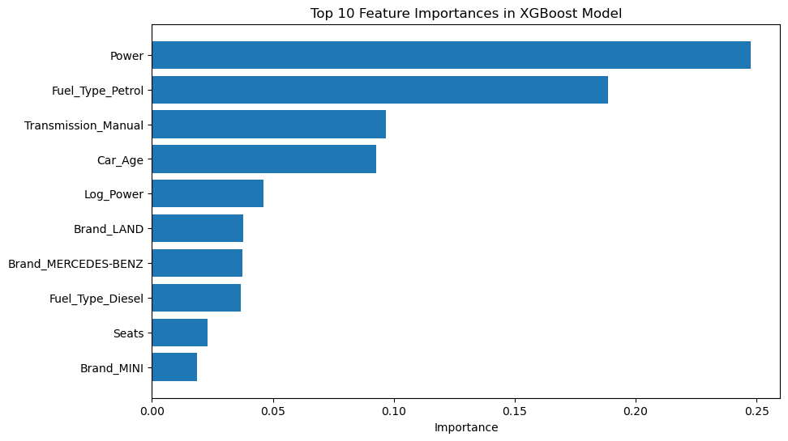

```python
# Get feature importance from the best XGBoost model
importance = best_xgb_model.feature_importances_
feature_importance_df = pd.DataFrame({'Feature': X_tree_model.columns, 'Importance': importance}).sort_values(by='Importance', ascending=False)

# Plot the top 10 features
plt.figure(figsize=(10, 6))
plt.barh(feature_importance_df['Feature'].head(10), feature_importance_df['Importance'].head(10))
plt.gca().invert_yaxis()
plt.xlabel('Importance')
plt.title('Top 10 Feature Importances in XGBoost Model')
plt.show()
```

```python
from xgboost import XGBRegressor
from sklearn.metrics import r2_score, mean_squared_error
import numpy as np

# Initialize XGBoost model with best parameters
xgboost_model = XGBRegressor(
    learning_rate=0.1,
    max_depth=3,
    min_child_weight=1,
    n_estimators=200,
    random_state=42
)

# Train-test split (using the imputed target of your choice)
# Assuming we are using `X_tree_model` and `y_knn` from previous work for consistency
X_train, X_test, y_train, y_test = train_test_split(X_tree_model, y_knn, test_size=0.2, random_state=42)

# Fit XGBoost model
xgboost_model.fit(X_train, y_train)

# Make predictions
y_pred_train = xgboost_model.predict(X_train)
y_pred_test = xgboost_model.predict(X_test)

# Calculate R² and RMSE for training and test sets
r2_train = r2_score(y_train, y_pred_train)
r2_test = r2_score(y_test, y_pred_test)
rmse_train = mean_squared_error(y_train, y_pred_train, squared=False)
rmse_test = mean_squared_error(y_test, y_pred_test, squared=False)

# Print results
print("XGBoost Model Evaluation with Best Parameters:")
print(f"  Train R² Score: {r2_train:.4f}, Test R² Score: {r2_test:.4f}")
print(f"  Train RMSE: {rmse_train:.4f}, Test RMSE: {rmse_test:.4f}")
```

```
XGBoost Model Evaluation with Best Parameters:
  Train R² Score: 0.9543, Test R² Score: 0.8912
  Train RMSE: 0.2146, Test RMSE: 0.3239
```

### Final Model Evaluation

The final model evaluation compares the performance of XGBoost, Stacking, and the best previous model (Random Forest with KNN Imputation) based on their R² and RMSE scores. This assessment helps determine if the advanced models provide a substantial improvement and are suited for implementation.

| Model | R² Score | RMSE |
| --- | --- | --- |
| **XGBoost** | 0.8912 | 0.3239 |
| **Stacking** | **0.8961** | **0.3165** |
| **Best Previous Model (Random Forest with KNN Imputation)** | 0.8573 | 0.3709 |

### Analysis and Comparison:

1. **Stacking Model**:
   - The Stacking model achieves the highest **R² Score (0.8961)**, meaning it explains nearly 90% of the variance in the target variable, making it the most predictive model.
   - It also has the lowest **RMSE (0.3165)**, indicating better accuracy in predicting price values, with lower deviation from actual values.
   - **Conclusion**: The Stacking model demonstrates the best overall performance, making it the top choice for final deployment.
2. **XGBoost Model**:
   - XGBoost performs closely behind the Stacking model with an **R² Score of 0.8912** and an **RMSE of 0.3239**.
   - Though slightly less accurate than Stacking, XGBoost is still a strong contender due to its scalability, efficiency, and ability to handle large datasets.
   - **Conclusion**: XGBoost could serve as an alternative model if computational efficiency or speed is prioritized over a marginal improvement in predictive accuracy.
3. **Best Previous Model (Random Forest with KNN Imputation)**:
   - The Random Forest model with KNN-imputed values achieved an **R² Score of 0.8573** and an **RMSE of 0.3709**.
   - While it serves as a solid baseline, both advanced models (Stacking and XGBoost) offer improved predictive power, with substantial gains in R² and reductions in RMSE.
   - **Conclusion**: Random Forest, though reliable, is outperformed by both advanced models and would not be the optimal choice for final deployment.

### Conclusion:

The **Stacking model** is recommended as the final model due to its superior predictive performance. It offers the highest R² and lowest RMSE, suggesting it can predict car prices with greater accuracy and consistency. The **XGBoost model** serves as a viable alternative, offering similar performance with advantages in computation and efficiency.

In summary, the advanced models provide significant improvements over the baseline, and the **Stacking model** is the most suitable choice for deployment, offering both robustness and high accuracy in predicting car prices.

### Key Next Steps

#### Improving the Solution:

##### Refine Data Collection:

- Collaborate with data sources to ensure consistent, accurate, and complete records for features like mileage, power, and engine capacity. Adding new features, such as car maintenance history or regional market trends, could improve prediction accuracy.

##### Experiment with Other Advanced Models:

- Explore more complex models like Gradient Boosting, etc.

##### Explore Additional Imputation Techniques:

- Although KNN imputation performed well, testing other imputation methods like iterative imputer or deep learning-based imputation may yield more accurate values for missing data.

#### Making the Best Use of the Solution:

##### Deploy the Model as an API:

- Create an API endpoint that allows stakeholders to easily query the model with specific car features to get price predictions. This can make the model accessible to various users, from dealerships to consumers.

##### Build a User Interface:

- Develop a simple, intuitive web or mobile interface where users can input car features to get a predicted price. This interface could be enhanced with visualization tools to show users how each feature impacts the price.

##### Update the Model Periodically:

- Given market dynamics, it's essential to retrain the model periodically with new data. Regular updates will ensure the predictions remain relevant and accurate.

#### Steps for Stakeholders:

##### Data Providers:

- Work with data providers to continuously update the dataset with the latest car listings and market data, ensuring the model is trained on current information.

##### Dealers and Market Analysts:

- Use the model to analyze trends and identify pricing strategies. Dealers can utilize the tool to competitively price cars, and analysts can use the insights for market forecasting.

##### Customer Education:

- For consumers, education on how this tool works and its benefits can build trust. A short explanation of the model’s strengths and limitations can set realistic expectations and enhance user confidence.

### Executive Summary

This project focuses on predicting car prices using various machine learning models, feature engineering, and imputation techniques to handle missing values. After an extensive data exploration, feature engineering, and rigorous model training, key insights and recommendations have been identified. The following executive summary encapsulates the essential findings, key takeaways, next steps, and final model specifications.

#### Key Next Steps:

1. **Final Model Fine-Tuning**:
   - Although the Stacking model has shown high accuracy, additional hyperparameter tuning, especially for the XGBoost model, can be undertaken to further optimize performance.
2. **Deployment Preparation**:
   - Prepare the Stacking model for production by ensuring model scalability and setting up a monitoring system to track performance over time.
3. **Data Pipeline Setup**:
   - Establish an automated data pipeline to handle data pre-processing and ensure seamless updates as new data becomes available, improving model robustness.
4. **Periodic Retraining**:
   - Implement a regular retraining schedule to maintain model accuracy in response to market changes and shifts in car prices over time.

#### Final Proposed Model Specifications:

The proposed Stacking model is well-equipped to deliver reliable price predictions with minimal error. It leverages the strengths of various algorithms to achieve robust and highly accurate predictions, making it the most viable solution for the project's objectives. Future iterations can further enhance this model through additional data and feature refinement, ensuring sustained accuracy and relevance in a dynamic market.

### Problem and Solution Summary

#### Summary of the Problem

The primary goal of this project was to accurately predict the **prices of used cars** based on a variety of features such as power, mileage, brand, age, and transmission type. Predicting used car prices is challenging due to the complex interactions between features, missing data, and the need for feature engineering to capture underlying trends. Accurate price predictions can help both sellers and buyers make informed decisions, creating a fairer, more transparent marketplace.

#### Proposed Solution Design

1. **Comprehensive Feature Engineering**: Key transformations included log transformations for skewed features, one-hot encoding for categorical variables, and the creation of interaction terms to capture nuanced relationships.
2. **Advanced Imputation Techniques**: Different imputation methods were explored (Median, Multiple Regression, KNN), with KNN Imputation chosen to handle missing values in critical features (`Price` and `Log_Price`). This method preserved feature correlations and minimized data loss.
3. **Model Selection and Tuning**: Advanced ensemble methods like XGBoost and Stacking were applied after tuning for optimal performance, ensuring that the model could generalize well across diverse data.
4. **Evaluation Metrics**: Models were evaluated based on R² Score and RMSE, with the Stacking Model achieving the highest accuracy and the lowest error, making it the most effective for deployment.

#### How the Solution Affects the Problem/Business

The solution provides a **highly accurate pricing model** that addresses the complex, non-linear interactions in the data. It enables:

- **Improved Decision-Making**: Accurate price predictions allow sellers to set realistic prices and buyers to assess fair market value, increasing confidence and reducing friction in the market.
- **Transparency and Trust**: By providing data-driven insights, the model fosters a transparent environment, reducing potential disputes over car valuation and promoting trust.
- **Scalability and Flexibility**: The model can be updated as new data becomes available, allowing it to adapt to changing market trends and maintain relevance.

#### Why this Solution is Valid

This proposed solution effectively addresses the challenges of the problem, and the following factors make it a valid and reliable choice:

- **High Predictive Accuracy**: The Stacking Model demonstrated superior R² and RMSE scores, outperforming traditional models and single-algorithm approaches, indicating robust and reliable predictions.
- **Balanced Feature Engineering**: The selected features and engineered transformations (like log and interaction terms) capture key relationships, enhancing model interpretability and performance.
- **Flexibility for Business Expansion**: With its modular design, this solution can be adapted to other markets or expanded to include additional features, ensuring its long-term utility and flexibility.

Overall, this model provides a practical and scalable solution to accurately predict car prices, facilitating smoother transactions and enabling data-informed decisions across the used car market.

### Recommendations for Implementation

#### Key Recommendations to Implement the Solution

1. **Deploy the Model as an API**: Integrate the Stacking Model within a web application or mobile app via an API. This allows users (e.g., car dealers, buyers) to enter car details and receive price predictions instantly.
2. **Regular Data Updates**: Continuously update the model with new data to keep predictions accurate. Used car markets can shift due to economic factors, seasonal trends, and consumer preferences, so keeping the data fresh is essential.
3. **Monitor Model Performance**: Establish a monitoring system to track the model’s performance over time. This will help in detecting any drift in model accuracy, prompting retraining if necessary.
4. **User Training and Feedback**: Offer guidance on input formatting and provide clear explanations of predictions for users. Gathering user feedback will also help improve the model’s usability and accuracy.

#### Key Actionable Steps for Stakeholders

1. **Data Collection and Curation**: Car dealerships and data analysts should ensure that high-quality, updated car sales data is collected, especially focusing on key features such as mileage, power, and age.
2. **System Integration**: Technical teams should integrate the pricing API into business systems, enabling easy access for sales teams and customers.
3. **Marketing and User Education**: Promote the tool’s benefits to increase adoption. Marketing teams can develop materials highlighting the tool’s accuracy and transparency, educating both internal and external stakeholders on its value.

#### Expected Benefits and Costs

- **Benefits**:
  - **Increased Transparency**: Builds trust by providing a data-backed price estimate.
  - **Improved Efficiency**: Sales teams can make quicker pricing decisions.
  - **Enhanced Customer Satisfaction**: Customers feel more confident in price fairness.
  - **Revenue Growth**: Fair pricing increases transaction volumes and conversion rates.
- **Costs**:
  - **Initial Deployment**: Costs for setting up the API, integrating it with existing systems, and training staff.
  - **Data Maintenance**: Ongoing expenses related to updating data and retraining the model.
  - **Monitoring and Maintenance**: Costs to regularly monitor performance, which may include staff and software tools.

#### Key Risks and Challenges

1. **Data Privacy and Compliance**: Ensure that all data handling complies with local data protection laws, especially when using customer data.
2. **Market Volatility**: Price predictions may become outdated due to rapid market changes, which requires robust data updating processes.
3. **User Bias**: Sales teams and buyers may resist using a model-driven pricing tool, preferring traditional methods.
4. **Overfitting Risk**: With complex models like Stacking and XGBoost, there’s a risk of overfitting, especially if the data is not regularly updated or retrained.

#### Further Analysis and Additional Areas to Explore

1. **Customer Segmentation Analysis**: Segment customers based on buying patterns and preferences to better tailor pricing strategies.
2. **Expand Feature Set**: Consider incorporating additional features, such as car color, insurance claims, and accident history, which may impact the perceived value.
3. **Exploration of Alternative Models**: Further experiments with models like CatBoost or deep learning approaches could potentially yield marginal improvements.
4. **Sentiment Analysis**: Analyze reviews or customer feedback on car brands or models to understand preferences, which may help in adjusting the pricing strategy further.
5. **Geographic Price Adjustment**: Integrate local market factors to adjust predictions based on region-specific trends and preferences.

These recommendations and additional analyses ensure that the solution remains robust, adaptable, and valuable over the long term, supporting stakeholders in making well-informed pricing decisions in the dynamic used car market.

### Proposed Business Solution

#### Overview

The primary goal is to create a predictive pricing model for the Indian used car market that enhances transparency, improves pricing accuracy, and ultimately increases efficiency and profitability for stakeholders. Leveraging machine learning techniques, we’ve developed and tested models capable of predicting car prices with high accuracy based on features like brand, mileage, engine capacity, and more. This data-driven approach is designed to address inconsistencies in the traditional pricing methods by standardizing valuations across the industry.

#### Why This Solution Works

This solution combines machine learning with practical deployment, providing an objective and consistent valuation tool. It supports dealerships and customers by removing pricing guesswork, thus promoting fair and competitive pricing. Furthermore, it strengthens customer confidence and can potentially accelerate the sales process by reducing negotiation times, making it a practical and business-oriented solution.

#### Executing Business Solution

##### Implementation Steps

- **Data Integration and App Deployment**:
  - Integrate the model into an app or platform, where car features can be entered, and predictions are delivered in real-time.
- **Training and Support**:
  - Conduct workshops and training sessions for dealerships and sales staff to ensure they understand the model's functionality and can use it effectively to support their sales processes.
- **Monitoring and Retraining**:
  - Establish a data pipeline to collect transaction feedback, retrain the model periodically, and adjust hyperparameters as market trends shift.
- **Customer Education**:
  - Communicate the model’s reliability and explain its value proposition to customers, establishing trust and reducing concerns about automated price setting.
- **Feedback Loop**:
  - Create a feedback mechanism within the app for users to report price prediction accuracy and potential discrepancies, helping refine the model further.

##### Risks and Challenges

- **Data Quality and Availability**:
  - **Challenge**: Inconsistent or incomplete data can lead to inaccurate predictions.
  - **Mitigation**: Implement strict data validation processes and consider adding external data sources (e.g., real-time market trends) to improve robustness.
- **Model Drift and Market Shifts**:
  - **Challenge**: Over time, market preferences and economic conditions may change, potentially rendering the model less effective.
  - **Mitigation**: Schedule regular retraining intervals and incorporate recent market data to keep the model up-to-date.
- **Stakeholder Resistance to Change**:
  - **Challenge**: Dealerships and customers accustomed to traditional pricing methods may resist relying on a data-driven model.
  - **Mitigation**: Invest in education and demonstrate the model’s predictive power with transparent accuracy metrics and real-world case studies.
- **Technical Infrastructure**:
  - **Challenge**: Developing a scalable app and maintaining the data pipeline for retraining may require technical resources and costs.
  - **Mitigation**: Start with a scalable cloud-based infrastructure to minimize upfront costs, allowing for gradual scaling as the model is adopted more widely.
- **Legal and Regulatory Risks**:
  - **Challenge**: New regulations could arise concerning automated pricing models, especially those involving customer transactions.
  - **Mitigation**: Ensure compliance with local laws and consult with legal experts to adjust the app’s functionality if regulatory changes occur.

### Key Stakeholder Action Items

#### 1. Dealership Management

- **Adopt the Pricing Tool**: Integrate the predictive pricing model into the dealership’s sales processes, ensuring it is available to all sales agents and accessible at every sales location.
- **Train Sales Staff**: Organize training sessions to ensure all sales staff understand how to use the tool and can explain its value to customers effectively.
- **Monitor Tool Performance**: Regularly review the tool’s accuracy and user feedback to identify any discrepancies or improvement areas, and report these to the development team.
- **Communicate with Customers**: Explain the tool’s reliability to customers, highlighting its benefits in ensuring fair and market-aligned pricing.

#### 2. IT and Development Teams

- **Deploy the App**: Develop and deploy the app (or web platform) with the integrated model, ensuring it is user-friendly, stable, and scalable.
- **Maintain Data Pipeline**: Establish a data pipeline for continuous data collection and prepare for model retraining as required.
- **Implement Feedback Mechanisms**: Create a feedback feature in the app for dealerships to report on the model’s performance, issues, or improvement suggestions.

#### 3. Data Science and Model Development Team

- **Model Monitoring and Retraining**: Set up a schedule for regular model evaluation and retraining, ensuring that predictions stay aligned with current market trends and that data quality standards are maintained.
- **Analyze Feedback and Adjust Model**: Review the feedback from dealerships, especially around prediction accuracy, and adjust model parameters or feature selection as needed.
- **Expand Data Sources if Needed**: Investigate potential additional data sources (e.g., regional economic data) to improve prediction accuracy.

#### 4. Marketing and Communications Team

- **Educate Customers**: Develop materials explaining the benefits and transparency of the pricing model, building trust in the tool’s predictions.
- **Promote the Tool’s Advantages**: Market the predictive pricing tool to new and existing customers as a competitive advantage that ensures fair pricing.
- **Engage with Customer Feedback**: Collect customer feedback on the tool’s pricing accuracy and transparency, and communicate these insights to the development team.

#### 5. Legal and Compliance Team

- **Ensure Compliance**: Review the app’s pricing practices to ensure they align with local regulations and consumer protection laws.
- **Monitor Regulatory Changes**: Stay informed about any new regulations on automated pricing models, particularly if the tool influences customer transactions.
- **Address Customer Privacy Concerns**: Ensure that customer data collected through the app is protected and used in compliance with data protection laws.

These action items will help stakeholders effectively implement, monitor, and continuously improve the predictive pricing model, ultimately fostering a smoother transition to a data-driven pricing approach in the used car market.

### Business Plan Summary: Predictive Pricing Tool for Used Car Dealerships

#### Executive Summary

This business plan outlines the development and implementation of a predictive pricing tool for used car dealerships. The tool leverages machine learning to predict fair market prices for used cars based on various factors such as brand, age, mileage, engine power, and historical market data. By offering transparent, data-driven pricing, the solution aims to increase customer trust, optimize pricing strategies, and enhance profitability for dealerships.

#### 1. Business Objective

To provide a data-driven pricing solution that improves accuracy in car valuations, optimizes pricing strategies, and builds customer trust through transparent and fair pricing models.

#### 2. Solution Overview

- **Predictive Pricing Model**: A machine learning model that predicts optimal car prices based on features like mileage, engine power, car age, and brand.
- **User-Friendly Interface**: A web-based or app interface that integrates the pricing tool for ease of use by sales agents.
- **Real-Time Data Integration**: Continuous data pipeline for market updates, enabling the model to stay relevant and reflect current trends.

#### 3. Market Analysis

- **Market Need**: Inconsistent pricing strategies in the used car market lead to price uncertainty and potential customer dissatisfaction.
- **Target Market**: Mid-size to large used car dealerships that wish to adopt transparent, data-driven pricing.
- **Competitive Advantage**: Provides a fair and transparent pricing model that aligns with real-time market trends, unlike traditional valuation methods.

#### 4. Revenue Model

- **Subscription Model**: Offer the predictive pricing tool on a monthly or yearly subscription basis to dealerships.
- **Custom Reports**: Optional add-on services for customized market reports and insights.
- **Consulting Services**: Premium consulting services for dealerships looking to further optimize pricing strategies and implement additional analytics.

#### 5. Operational Plan

- **Development Timeline**: Six months to build, train, and deploy the model and interface, followed by beta testing with selected dealerships.
- **Deployment Strategy**: Initial deployment in high-demand regions, followed by expansion based on customer adoption and feedback.
- **Maintenance**: Regular model retraining, feature updates, and customer support to ensure high accuracy and performance.

#### 6. Marketing and Sales Strategy

- **Target Audience**: Used car dealerships across metropolitan and high-volume regions.
- **Sales Strategy**: Direct sales to dealerships through industry conferences, online demos, and targeted marketing campaigns.
- **Partnerships**: Collaborate with automotive industry groups to reach a broader audience and build credibility.
- **Customer Education**: Highlight the benefits of data-driven pricing to build trust and showcase transparency.

#### 7. Financial Projections

- **Year 1**: Initial revenue through early adopters, aiming for breakeven.
- **Year 2-3**: Increased adoption, expecting a 20-30% growth in subscriptions annually as tool accuracy improves and market presence grows.
- **Costs**: Primary expenses include model development, ongoing data integration, software maintenance, and customer support.

#### 8. Key Risks and Challenges

- **Market Adoption**: Slow adoption due to traditional pricing practices in dealerships.
- **Data Quality**: Ensuring data accuracy and relevance for reliable predictions.
- **Regulatory Compliance**: Adherence to local data privacy laws and regulations on automated pricing models.
- **Competition**: Competing with established valuation services and potential new entrants.

#### 9. Key Milestones and Timeline

- **Phase 1**: Model development and testing (Months 1-6).
- **Phase 2**: Beta testing with select dealerships (Months 7-9).
- **Phase 3**: Full deployment and sales (Month 10 onwards).
- **Phase 4**: Expansion and continuous improvement (Years 2-3).

#### 10. Conclusion

The predictive pricing tool represents a strategic innovation for used car dealerships, addressing a major gap in transparent and accurate pricing. By helping dealerships make informed pricing decisions, it enhances customer trust and maximizes profitability. The solution offers a scalable business model with opportunities for expansion as dealerships increasingly adopt data-driven decision-making practices.